# Hypothesis Testing

[figure not shown]

# Introduction

**Audience:** Someone with working knowledge of Python and knows statistical test (such as t-test and chi-square test) and how to run those test in Python, and now interested in learning about conducting power analysis in Python, the type of errors in hypothesis testing and calculating their probabilities.

**Prerequisite:** Introduction to Python and Statistical Test (in the pre-course information folder)

**Description:** This is a short course on hypothesis testing, it mainly covers the type of errors while conducting a hypothesis test, calculating the probability of those errors, conducting a power analysis to find the power and sample size of a test. Firstly, the theory will be shown, then an example of how to apply the corresponding theory in python will be shown, and lastly, there will be an exercise for learners to be completed.

# Packages

Make sure to install all of these packages beforehand and load in these packages before starting this course. The main packages we will be using for this course are:

- “pandas” (Version 1.1.5 ) for importing data sets
- “numpy” (Version 1.19.5) for data manipulation
- “pingouin” (Version 0.3.11) for conducting statistical test, calculating effect size and power analysis

Please contact your department if you are struggling to install these packages since these packages are essential.

# Learning Objectives

**The goal of this course is to:**

- Define Type I and Type II errors
- Calculate Probability of Type I error
- Calculating Effect Size
- Calculate Power and Probability of Type II error
- Calculate Sample Size

# 1 Data

In this course, we will be mainly using `airquality_data` stored in the `data` folder. So, you should create a Python script within the `Course content` folder and then set your working directory to this course content folder e.g. if you are working on jupyter notebook then `%cd names of folder paths/Course content` and if you are using Spyder then import `os` package and then use `os.chdir("names of folder paths/Course content")`. If you are not sure how to import the data set then please complete Introduction to Python course first.

## 1.1 Exercise

### **Exercise**

1. Import the following packages: `pandas`, `numpy` and `pingouin`.
2. Import the `airquality_data` from the data folder and assign it to the variable name `airquality`.
3. Look at the first 5 observations.
4. Drop a comment in your script specifying how many columns are in the `airquality` data and their column names.

### **Show Answer**

1. Import the following packages: `pandas`, `numpy` and `pingouin`.

```python
# Importing the following packages

import pandas as pd

import numpy as np

import pingouin as pg
```

2. Import the `airquality_data` from the data folder and assign it to the variable name `airquality`.

```python
# Load in the airquality_data from the data folder using pandas package and read_csv function
# then assign it to the name "airquality"

airquality = pd.read_csv("../Data/airquality_data.csv")
```

3. Look at the first 5 observations.

```python
# Looking at first 5 observations using head() function

airquality.head()
```

```
##       ozone     solar_r  wind  temp  month  day
## 0  41.00000  190.000000   7.4    67      5    1
## 1  36.00000  118.000000   8.0    72      5    2
## 2  12.00000  149.000000  12.6    74      5    3
## 3  18.00000  313.000000  11.5    62      5    4
## 4  42.12931  185.931507  14.3    56      5    5
```

4. Drop a comment in your script specifying how many columns are in the `airquality` data and their column names.

The data has 6 columns/variables:

**ozone** - Mean ozone concentration in parts per billion from 1300 to 1500 hours at Roosevelt Island.

**solar_r** - Solar radiation in Langleys in the frequency band 4000–7700 Angstroms from 0800 to 1200 hours at Central Park.

**wind** - Average wind speed in miles per hour at 0700 and 1000 hours at LaGuardia Airport.

**temp** - Maximum daily temperature in degrees Fahrenheit at LaGuardia Airport.

**month** - Daily air quality measurements in New York from May to September in 1973.

**day** - Daily air quality measurements for all days from May to September so the `Days` column can either have 30 days or 31 days depending on the corresponding month.

Now we will look at the dimensions of `airquality` data, unique values in the `month` column and also summary statistics of each variable.

```python
# Look at the dimensions of airquality data

airquality.shape
```

```
## (153, 6)
```

```python
# Find the unique values in the month column

airquality['month'].unique()
```

```
## array([5, 6, 7, 8, 9], dtype=int64)
```

```python
# Look at summary statistics of airquality data

airquality.describe()
```

```
##             ozone     solar_r        wind        temp       month         day
## count  153.000000  153.000000  153.000000  153.000000  153.000000  153.000000
## mean    42.129310  185.931507    9.957516   77.882353    6.993464   15.803922
## std     28.693372   87.960267    3.523001    9.465270    1.416522    8.864520
## min      1.000000    7.000000    1.700000   56.000000    5.000000    1.000000
## 25%     21.000000  120.000000    7.400000   72.000000    6.000000    8.000000
## 50%     42.129310  194.000000    9.700000   79.000000    7.000000   16.000000
## 75%     46.000000  256.000000   11.500000   85.000000    8.000000   23.000000
## max    168.000000  334.000000   20.700000   97.000000    9.000000   31.000000
```

# 2 Hypothesis testing

In hypothesis testing, you are performing statistical test to determine whether you believe a statement to be true or false. One common example of this is whether you believe two populations to be statistically different from one another. There are seven steps to follow when you are using any statistical test:

1. State the null hypothesis $H_{0}$ and alternative hypothesis $H_{a}$
2. Decide the significance level, $\alpha$
3. Compute the observed test statistics
4. Determine the critical value
5. Determine the p-value
6. Determine the confidence interval
7. Interpret your results

These steps are covered in the `Statistical_test` file in the `Pre_course_information` folder. In this course, we will run a t-test, see what potential error can occur while conducting hypothesis testing, and finally conduct a power analysis to minimise errors with hypothesis testing.

We will be using the `airquality` data to find out if the average temperature in May is significantly different from the average temperature in July. So, we will create two data frames that contains all observations in May and July respectively and then select the temperature column from both data sets as shown below:

```python
# Here we are filtering airquality data to get two data frames
# first consist of observations in May and second consist of observations in July

may = airquality[airquality['month'] == 5]

july = airquality[airquality['month'] == 7]

# Then select the temperature column

temp_may = may['temp']

temp_july = july['temp']
```

Then we will construct a two-tailed test where the null hypothesis and alternative hypothesis are shown below:

$H_{0}:$ Mean temperature in May is the same as the mean temperature in July

$H_{a}:$ Mean temperature in May is different from the mean temperature in July

Then we will run a t-test as shown below:

```python
# Run two-sided independent t-test where x and y needs to be an array-like or float,
# paired = False means the groups are independent,
# correction = auto means it will automatically use Welch t-test (variance unequal),
# our alpha is 0.05

t_test_temp = pg.ttest(x=temp_may, y=temp_july, paired=False,
                  tail='two-sided', correction='auto', confidence=0.95)

# Display the observed statistics
# by specifying the name of the variable
# or using print() function if you are using spyder

t_test_temp['T']
```

```
## T-test   -12.616439
## Name: T, dtype: float64
```

```python
# Display the p-value

t_test_temp['p-val']
```

```
## T-test    1.580321e-18
## Name: p-val, dtype: float64
```

```python
# Display the 95% CI

t_test_temp['CI95%']
```

```
## T-test    [-21.26, -15.44]
## Name: CI95%, dtype: object
```

> **Reminder:** If you are using Jupyter Notebook or RStudio then you can print your output by specifying the variable name however if you are using Spyder then you need to use the `print()` function to print output.

From the output, we can see that the average temperature between May and July is statistically significant at a 5% significance level, as:

- **Critical Value Approach:** The t-value is less than $\pm 2.0003$
- **P-value Approach:** The p-value is less than 0.05
- **Confidence Interval:** The 95% confidence interval does not contain 0

Hence, we can reject the null hypothesis at a 5% significance level which suggests that the average difference in temperature between May and July is statistically significant.

> If you didn’t understand the output and approaches we took to make this decision, then please look at the Statistical test file in the pre-course information folder.

## 2.1 Exercise

### **Exercise**

We want to find out whether the average ozone concentration in June is significantly different from the average ozone concentration in July.

1. Construct the null hypothesis and alternative hypothesis.
2. Create two vectors (one-dimensional arrays) representing ozone concentration in June and July.
3. Carry out a two-sample independent t-test to find out whether the average ozone concentration in June is significantly different from the average ozone concentration in July.

### **Show Answer**

We want to find out whether the average ozone concentration in June is significantly different from the average ozone concentration in July.

1. Construct the null hypothesis and alternative hypothesis.

$H_{0}:$ Mean ozone concentration in June is the same as the mean ozone concentration in July

$H_{a}:$ Mean ozone concentration in June is different from the mean ozone concentration in July

2. Create two vectors (one-dimensional arrays) representing ozone concentration in June and July.

```python
# I am filtering airquality data which consists of observations for June only
# then I am selecting ozone concentration from the filtered data


exercise_june = airquality[airquality['month'] == 6]
ozone_june = exercise_june['ozone']

# I am filtering airquality data which consists of observations for July only
# then I am selecting ozone concentration from the filtered data

exercise_july = airquality[airquality['month'] == 7]
ozone_july = exercise_july['ozone']
```

3. Carry out a two-sample independent t-test to find out whether the average ozone concentration in June is significantly different from the average ozone concentration in July.

```python
# Run a two-sided independent t-test where x and y need to be an array-like or float.
# parameter paired = False means the groups are independent,
# parameter correction = auto means it will automatically use Welch t-test (variance unequal),
# our alpha is 0.05

t_test_ozone = pg.ttest(x=ozone_june, y=ozone_july, paired=False,
                        tail='two-sided', correction='auto', confidence=0.95)

# Display the p-value
# by specifying the name of the variable
# or using print() function if you are using spyder

t_test_ozone['p-val']
```

```
## T-test    0.002972
## Name: p-val, dtype: float64
```

```python
# Display the 95% CI

t_test_ozone['CI95%']
```

```
## T-test    [-29.57, -6.53]
## Name: CI95%, dtype: object
```

Since the p-value is less than $\alpha = 0.05$ and the confidence interval does not contain 0, we reject the null hypothesis at a 5% significance level, hence the average difference in ozone concentration between both months is statistically significant.

# 3 Type I error and Type II error

After conducting a hypothesis test, we decide whether to reject the null hypothesis or not. However, this can never be said with complete certainty as we are working with probabilities. There is always a chance of making an incorrect decision which leads us to two errors:

- **Type I error:** is also known as a false positive, and occurs when a researcher incorrectly rejects a null hypothesis when in reality it is true.
- **Type II error:** is also known as a false negative, and occurs when a researcher does not reject a null hypothesis when in reality it is false.

[figure not shown]

Continuing with the `airquality` example, when we are conducting the following hypothesis:

$H_{0}:$ Mean temperature in May is the same as the mean temperature in July.

$H_{a}:$ Mean temperature in May is different from the mean temperature in July.

Then the Type I and II errors are as follows:

- **Type I error (false positive):** concluding that there is a difference in mean temperature of both months (rejecting $H_{0}$), but in reality, the mean temperature of both months are the same ($H_{0}$ is true).
- **Type II error (false negative):** concluding that the mean temperature of both months are the same (not rejecting $H_{0}$), but in reality, there is a difference in the mean temperature of both months ($H_{0}$ is false).

# 4 Probability of Type I error

Now we know what type I and type II errors are, but in real life, we are interested in learning about the probabilities of these errors. The probability of making a type I error (also known as type I error rate) is the significance level, denoted as $\alpha$. We are now going to do some simulations to compute an empirical probability of type I error (type I error rate) and check that it is approximately equal to $\alpha$, basing the test decisions on the p-values returned by the t-test.

Suppose that $X_1, X_2,..., X_{20}$ is a random sample where X is the temperature in May and $X \sim N(\mu,6^2)$. We are interested in testing if the mean temperature in May is greater than 50 degrees Fahrenheit or not.

```python
# Create a variable and name it simulations
# function float will give us the value of p-value from t-test instead of type and value
# then run one-sided t-test where x is a random sample from the normal distribution,
# with mean 50 and the standard deviation is 6
# and y is just 50 because we want to test if the mean temperature in May is greater than 50
# select p-value from t-test and run this t-test 10000 times

simulations = [float(pg.ttest(x=np.random.normal(loc=50, scale=6,
                     size=20), y=50, paired=False, tail='greater',
                     correction='auto', confidence=0.95)['p-val'])
                     for _ in range(10000)]


# Check which p-values are less than alpha = 0.05 in the simulations

pvalue_less_alpha = [pvalue < 0.05 for pvalue in simulations]

# Find the mean of p-values that are less than alpha
# this gives the probability of type one error

prob_type_one_error = np.mean(pvalue_less_alpha)


prob_type_one_error
```

```
## 0.0503
```

As you can see the probability of type one error is approximately equal to the significance level which in our case is $\alpha = 0.05$, so that means there is a 5% chance that we may reject the null hypothesis when it is true (false positive). So there is a 5% chance that we conclude that the mean temperature in May is greater than 50 degrees Fahrenheit when in reality it is not.

## 4.1 Exercise

### **Exercise**

1. Suppose that $X_1, X_2,..., X_{30}$ is a random sample where X is the ozone concentration in June and $X \sim N(\mu,\sigma^2)$. We are interested in finding the probability of type I error while testing if the mean ozone concentration in June is less than 40 parts per billion or not. Use $\alpha= 0.01$ and sigma is the standard deviation of ozone concentration in June.

(**Hint:** use `np.std()` function to find the standard deviation of ozone concentration in June)

### **Show Answer**

1. Suppose that $X_1, X_2,..., X_{30}$ is a random sample where X is the ozone concentration in June and $X \sim N(\mu,\sigma^2)$. We are interested in finding the probability of type I error while testing if the mean ozone concentration in June is less than 40 parts per billion or not. Use $\alpha= 0.01$ and sigma is the standard deviation of ozone concentration in June.

(**Hint:** use `np.std()` function to find the standard deviation of ozone concentration in June)

```python
# Create a variable called simulations
#  function float will give us the value of p-value from t-test instead of type and value
# run one-sided t-test where x is a random sample from the normal distribution,
# with mean 40 and standard deviation is np.std(ozone_june)
# and y is just 40 because we want to test if the ozone concentration in June is less than 40
# select p-value from t-test and run this t-test 10000 times

simulations = [float(pg.ttest(x=np.random.normal(loc=40,
                     scale=np.std(ozone_june), size=30), y=40,
                     paired=False, tail='less', correction='auto',
                     confidence=0.99)['p-val'])
                     for _ in range(10000)]


# Check which p-values are less than alpha = 0.01 in the simulations

pvalue_less_alpha = [pvalue < 0.01 for pvalue in simulations]

# Find the mean of p-values that are less than alpha
# this gives the probability of type one error

prob_type_one_error = np.mean(pvalue_less_alpha)

prob_type_one_error
```

```
## 0.0103
```

The probability of type one error is approximately equivalent to the significance level which is $\alpha=0.01$. So we can interpret an alpha of 0.01 as a 1% chance that our results are due to chance rather than actual ozone concentration in June being less than 40 parts per billion.

# 5 Effect Size

When we conducted a t-test, we found that the average difference in temperature between May and July is statistically significant. However, we need to consider other factors that can make our results significant as well. Generally, when we increase the sample size, the p-value decreases which means that we are more likely to get a significant p-value even when the difference in outcomes between groups is negligible.

Therefore, even when the difference is statistically significant, it does not necessarily mean that it is big, important, or helpful in decision-making. It simply means you can be confident that there is a difference. To know if an observed difference is not only statistically significant but also important or meaningful, you will need to calculate its effect size. There are different ways to calculate effect size depending on the evaluation design you use. For example, when comparing two groups we typically use Cohen’s d. However, for regressions and correlations, the coefficient of determination $R^2$ and Pearson correlation coefficient $r$ effect size can be used respectively.

## 5.1 Cohen’s d

Cohen’s d is a common measure of effect size for t-test, and can be measured using the formula shown below:

$$\frac{M_{1}-M_{2}}{SD_{\text{pooled}}}$$

where,

- $M_1$ and $M_2$ represent the mean value of the group 1 and 2, respectively. In our case, it is the mean temperature in May and July.
- $SD_{\text{pooled}}$ is a weighted average of standard deviations for two groups. It is used when we assume that the variance of both groups is the same.

Pooled standard deviation is used, when we assume that the variance of both groups is the same. We can carry out the formal test to see if variances between groups are significantly different or not:

- **Bartlett’s test:** Compare the variances of k samples, where k can be more than two samples. The data must be normally distributed.
- **Levene’s test:** Compare the variances of k samples, where k can be more than two samples. It’s an alternative to Bartlett’s test that is less sensitive to departures from normality.

Now, we will check if the variance between the temperature in May and July are significantly different or not.

```python
# Create a new dataset and select temperature and month column

monthly_temp = airquality[['temp', 'month']]

# Filter out the temperature in May and July

temp_data = monthly_temp[(monthly_temp['month'] == 5) |
                         (monthly_temp['month'] == 7)]

# Run the test where the dependent variable is temp and grouping variable is the month
# the method is Levene's (default) but can change to ‘bartlett’s

pg.homoscedasticity(data=temp_data, dv='temp',
                    group='month', method='levene')
```

```
##                W      pval  equal_var
## levene  7.320055  0.008864      False
```

$H_0:$ The variances of temperature in May and July are the same

$H_a:$ The variances of temperature in May and July are different

Since the p-value is less than 0.05, we reject the null hypothesis and conclude that there is a significant difference between the variances of both groups. Also, the output `equal_val = False` confirms that there is a significant difference between the variances of both groups. Therefore we will use unpooled SD for Cohen’s d calculation, which means we will set the argument/parameter `paired = False` when calculating the effect size.

```python
# Calculate cohen's d using pg.compute_effsize()
# where x and y are the groups that you want to see the difference of
# parameter paired = False is used when we are assuming variance are not equal

effect_size_temp = pg.compute_effsize(x=temp_may, y=temp_july,
                   paired=False, eftype='Cohen')


round(effect_size_temp,3)
```

```
## -3.205
```

Cohen’s d is negative, which is expected since the mean temperature in May is less than the mean temperature in July. Since Cohen’s d is the magnitude of the mean difference between two groups, using absolute value/reversing the order is perfectly fine in this case. So, it is safe to say that the effect size is 3.205. However, in medical statistics, the sign of your Cohen’s d effect tells you the direction of the effect. For example, if M1 is your experimental group and M2 is your control group, a negative effect size indicates the effect decreases your mean, and a positive effect size indicates that the effect increases your mean.

Generally, a score of d = 1.0 means that the difference between the two groups is equal to one standard deviation. A score of d = 0.50 means that the difference between the two groups is equivalent to half of a standard deviation. The bigger the score, the bigger the difference between the groups and the bigger the effect. Here is a rough interpretation of cohen’s d values.

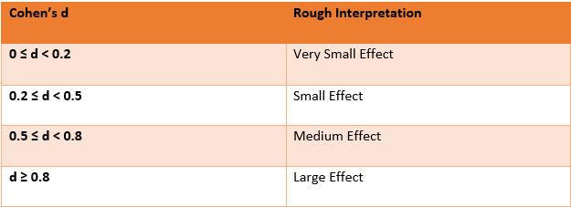

This means that if two group means don’t differ by 0.2 standard deviations or more, the difference is negligible, even if it is statistically significant. Note that, for a small sample size (< 50), Cohen’s d tends to over-inflate results. There exists a Hedge’s corrected version of Cohen’s d (Hedges and Olkin 1985), which provides a bias correction to Cohen’s d. Hedge’s g is also used when the sample sizes of the two groups are significantly different. The interpretation for both methods is the same.

```python
# Create two samples from temperature_may and temperature_july variable
# to make sure the sample sizes are significantly different we will use sample()
# to make my results reproducible I will use the random_state parameter


sample_may  = temp_may.sample(n=5, random_state=1)
sample_july = temp_july.sample(n=30, random_state=1)

# Use cohen and hedges effect size to see the difference in results

cohen = pg.compute_effsize(x=sample_may,y=sample_july,
                   paired=False, eftype='Cohen')

cohen
```

```
## -5.075239977361366
```

```python
# Use cohen and hedges effect size to see the difference in results

hedges = pg.compute_effsize(x=sample_may, y=sample_july,
                   paired=False, eftype='hedges')

hedges
```

```
## -4.9590131076508
```

### 5.1.1 Exercise

#### **Exercise**

1. Check if the variance of ozone concentration in June is significantly different from the average ozone concentration in July using Levene’s test.
2. We found in the earlier exercise that the average ozone concentration in June is significantly different from the average ozone concentration in July. Calculate the cohen’s d.
3. Interpret your results.
4. Use `help()` function to find more information about `pg.compute_effsize` function.

#### **Show Answer**

1. Check if the variance of ozone concentration in June is significantly different from the average ozone concentration in July using Levene’s test.

```python
# Create a new dataset and select ozone and month column

monthly_ozone = airquality[['ozone', 'month']]

# Filter out the ozone concentration in June and July

ozone_data = monthly_ozone[(monthly_ozone['month'] == 6) |
                          (monthly_ozone['month'] == 7)]

# Run the test where the dependent variable is ozone and the grouping variable is the month
# the method is Levene's (default) but can change to ‘bartlett’s

pg.homoscedasticity(data=ozone_data, dv='ozone',
                    group='month', method='levene')
```

```
##                 W      pval  equal_var
## levene  18.282724  0.000071      False
```

Since the p-value is less than 0.05, we reject the null hypothesis and conclude that there is a significant difference between the variances of both groups, which means we will set `paired = False` when calculating effect size.

2. We found in the earlier exercise that the average ozone concentration in June is significantly different from the average ozone concentration in July. Calculate the cohen’s d.

```python
# Calculate cohen's d
# where x and y are the groups that you want to see the difference of
# parameter paired = False is used when we are assuming variance are not equal

effect_size_ozone = pg.compute_effsize(x=ozone_july, y=ozone_june,
                   paired=False, eftype='Cohen')


round(effect_size_ozone,3)
```

```
## 0.802
```

An alternative way is to use the t-test as shown below:

```python
# Conduct t-test to see if mean ozone concentration in July is statistically,
# different from mean ozone concentration in June

t_test_ozone = pg.ttest(x=ozone_june, y=ozone_july, paired=False,
                    tail='two-sided', correction='auto',
                     confidence=0.95)

# Display the cohen d

t_test_ozone['cohen-d']
```

```
## T-test    0.801931
## Name: cohen-d, dtype: float64
```

3. Interpret your results.

The effect size is large.

4. Use `help()` function to find more information about `pg.compute_effsize` function.

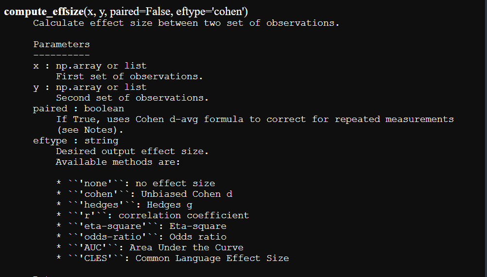

```python
# Finding information of compute_effsize function using help() function

help(pg.compute_effsize)
```

There are potentially hundreds of different measures of the effect size and you will be required to use effect size depending on your statistical models. You can use `pg.compute_effsize` to compute the effect size of some of the statistical methods by specifying the parameter/argument `eftype`.

- **T-test:** `cohens` is used for a larger sample size (greater than 50), `hedges` is used when the sample size of two groups are significantly different and the sample size is small (less than 50). There is a third type that is not included in this function but you can use `researchpy.ttest()` in the researchpy package to calculate the glass’s delta. Glass’s delta is used when two groups have a significantly different standard deviation, but this is used when you want to calculate the effect size between the experimental group and the control group.
- **Pearson correlation coefficient:** choose the `eftype = 'r'`.
- **Odds ratio:** when using `pg.compute_effsize` choose `eftype = 'odds-ratio'`.
- **One-way ANOVA test:** choose `eftype = 'eta-square'`
- **Chi-squared test of independence or goodness-of-fit:** we can use `pg.chi2_independence` to get the value for cramer.
- **Linear regression:** coefficient of determination ($R^2$) is used as effect size (see Statistics for Data Science in Python course to learn about linear regression)

# 6 Probability of Type II error

So far we have learnt that increasing the sample size results in decreasing p-value, which means a significant p-value is likely to be found. However, decreasing the sample size means we might commit a Type II error.

**Reminder:** Type II occurs when a researcher does not reject a null hypothesis when in reality the null hypothesis was false.

[figure not shown]

The probability of making a type II error is called Beta $(\beta)$, and this is related to the power of the statistical test. Power is the probability of making a correct decision (to reject the null hypothesis) when the null hypothesis is false. It can also be described as the probability of avoiding a Type II error. Mathematically, we can write power as $power = 1- \beta$.

## 6.1 Calculating power

```python
# The pg.power_ttest2n function is used for two-sample t-test (unequal sample sizes)
# specify the effect size as d
# we want to calculate the power so set it to None
# specify the significance level to be 0.05
# and specify the alternative hypothesis which is 'two-sided' in our case

pg.power_ttest2n(nx=31, ny=30, d=0.81, power=None, alpha=0.05, tail='two-sided')
```

```
## 0.8751093694181669
```

This gives us a power of 0.875. Hence the probability of committing Type II error (denoted by $\beta$ ) is $\beta = 1- \text{Power} = 1- 0.875 = 0.125$.

Let’s use the `pg.power.power_ttest()` function (which is used to calculate the power of two-sample, one-sample, independent and paired t-test for the equal sample size of both groups), to check the effect of sample size on power.

```python
# Creating a sequence of sample sizes using power calculations for t-test
# where d is the medium effect size which is 0.5

sample_size = np.arange(start=10, stop=100, step=10)

power_sample = pg.power_ttest(d=0.5, n=sample_size, alpha=0.05)

# Create a data frame that shows the sample size
# and corresponding power rounded to 2 decimal places

pd.DataFrame({'n': sample_size,
              'power': np.round(power_sample, 2)})
```

```
##     n  power
## 0  10   0.19
## 1  20   0.34
## 2  30   0.48
## 3  40   0.60
## 4  50   0.70
## 5  60   0.78
## 6  70   0.84
## 7  80   0.88
## 8  90   0.92
```

This shows that increasing sample size increases the power of a test. Just like how $\alpha$ is set by researchers (usually 0.05 or lower), Beta ($\beta$) is also commonly set at 0.2 or lower by researchers. Hence power ( 1-$\beta$ ) is usually set to 0.8 or higher. Powers lower than 0.8 are not impossible, but would typically be considered too low for most areas of research. In reality, a researcher would want both Type I and Type II errors to be small. In terms of significance level and power this means we want a small significance level (close to 0) and a large power (close to 1).